# Notebook

### Data Set 5

```
Benchmark
	The best-fit value: a = -1.333069, b = -0.241305
	The square-loss from standard linear fit: 338.1255
MLE approach
	The best-fit value: a = -1.118841, b = -0.127338
	The square-loss from the base model: 331.3269
```

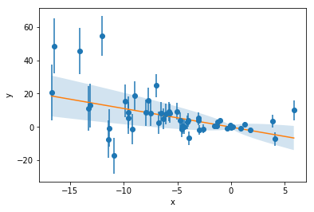

```python
data_set = 5
x, y = load_data(data_set)
a_, b_ = MLE(x=x, y=y, plot_flag=True)
```

```
Multiprocess sampling (4 chains in 4 jobs)
NUTS: [a_interval__, b_interval__]
```

```
MAP approach for base model
	The best-fit value: a = -1.267592 with sd = 0.1410, b = -0.374890 with sd = 0.0150
	The square-loss from the base model: 336.5115
```

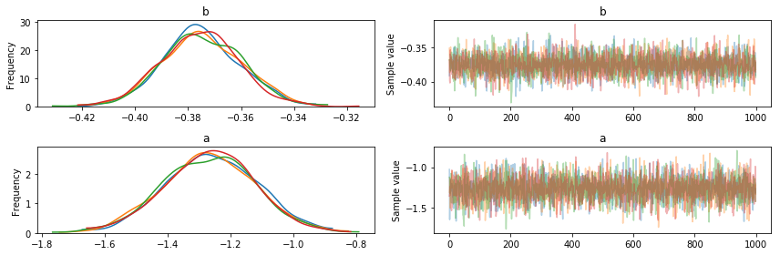

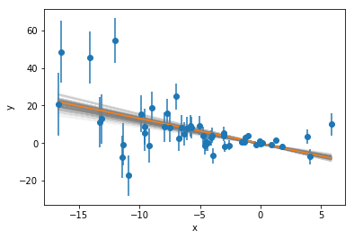

```python
a_, b_ = MAP_base(a_guess=a_, b_guess=b_, x=x, y=y, plot_flag=True)
```

```
Multiprocess sampling (4 chains in 4 jobs)
NUTS: [a_interval__, b_interval__, e_interval__, d, c]
There were 37 divergences after tuning. Increase `target_accept` or reparameterize.
There were 61 divergences after tuning. Increase `target_accept` or reparameterize.
There were 58 divergences after tuning. Increase `target_accept` or reparameterize.
There were 52 divergences after tuning. Increase `target_accept` or reparameterize.
```

```
MAP approach for advanced model
	The best-fit value: a = -0.423160 with sd = 0.2367, b = 0.297367 with sd = 0.4212
	The square-loss from the advanced model: 123.6330
```

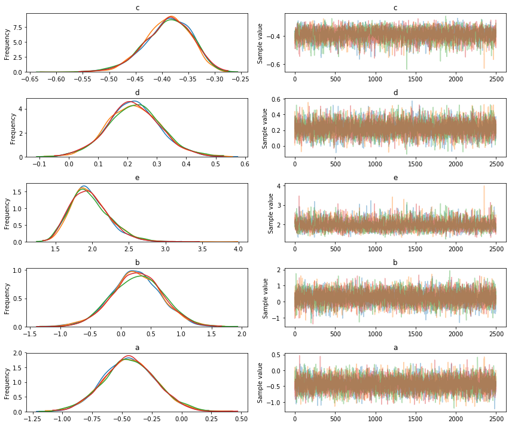

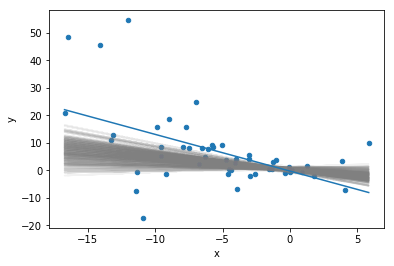

```python
a_, b_ = MAP_ad(a_guess=a_, b_guess=b_, x=x, y=y, plot_flag=True)
```

```python
result.append(["data_1_{}.csv".format(data_set), a_, b_])
result[data_set-1]
```

```
['data_1_5.csv', -0.4231604812616002, 0.29736732855110826]
```

```python
result
```

```
[['data_1_1.csv', 1.0595345555052258, 0.07734621028176958],
 ['data_1_2.csv', 1.2151158827281496, -0.7044785164742667],
 ['data_1_3.csv', -0.44028431960494835, 0.25814827042720206],
 ['data_1_4.csv', 0.5014516571437767, 0.9376692741838497],
 ['data_1_5.csv', -0.4231604812616002, 0.29736732855110826]]
```

```python
with open('result_MAP.csv','w') as fp:
    fp.writelines('\t'.join(str(it) for it in line) + '\n' for line in result)
```

## Result Summary

- Benchmark model is the standard least-square linear fit with assumption of Gaussian noise with constant variance over any parameter, which is not the case here.
- Rest of the models only explore a $x$-dependent Gaussian noise. Other noise distribution should be used if physical reason exists.
- The MLE approach is equivalent to loss function optimization. The benefit of MLE is analytical solution exists by straightforward linear algebra.
- In Bayesian statistics, frequentism is solving the wrong problem.
  - MLE approach assumes a deterministic model exists with some true parameters. It tries to fit the data to such a model at the maximum extend with maximum likelihood of $f(X|\theta)$ (how likely to get data $X$ if the parameter is $\theta$).
  - It might be the case of this problem (if data is generated from a handcrafted model) but it usually doesn't hold in real-world.
  - As the problem requested, to derive a good estimator for the parameters based on observed data, MAP approach incorporates the prior distribution of pre-knowledge with the sampling distribution of the data to marginalize the posterior $f(\theta|X)$, which answers to how likely the model is $\theta$ given the observed data is $X$.
- The base model assumes linear dependency of the noise variance over $x$.
- The advance model assumes polynomial dependency of the noise variance over $x$.

### Data Set 1

```
Benchmark
    The best-fit value: a = 0.880809, b = -0.269527
    The square-loss from standard linear fit: 484.6278

MLE approach
    The best-fit value: a = 0.924112, b = 0.038162
    The square-loss from the base model: 477.7449

MAP approach for base model
    The best-fit value: a = 0.941691 with sd = 0.1051, b = 0.200148 with sd = 0.0212
    The square-loss from the base model: 479.6316

MAP approach for advanced model
    The best-fit value: a = 1.058664 with sd = 0.2020, b = 0.082784 with sd = 0.3063
    The square-loss from the advanced model: 218.3054
```

### Data Set 2

```
Benchmark
    The best-fit value: a = 1.285603, b = -0.395853
    The square-loss from standard linear fit: 1275.1328

MLE approach
    The best-fit value: a = 1.272313, b = -0.806160
    The square-loss from the base model: 1269.6213

MAP approach for base model
    The best-fit value: a = 1.635213 with sd = 0.0985, b = -0.836088 with sd = 0.0413
    The square-loss from the base model: 1321.0587

MAP approach for advanced model
    The best-fit value: a = 1.217881 with sd = 0.1946, b = -0.636866 with sd = 0.5518
    The square-loss from the advanced model: 576.2822
```

### Data Set 3

```
Benchmark
    The best-fit value: a = -0.537850, b = 4.175155
    The square-loss from standard linear fit: 769.7736

MLE approach
    The best-fit value: a = -0.469547, b = 0.533146
    The square-loss from the base model: 642.4036

MAP approach for base model
    The best-fit value: a = -0.407798 with sd = 0.1446, b = -0.911191 with sd = 0.1301
    The square-loss from the base model: 663.3336

MAP approach for advanced model
    The best-fit value: a = -0.440284 with sd = 0.2384, b = 0.258148 with sd = 0.6257
    The square-loss from the advanced model: 308.8886
```

### Data Set 4

```
Benchmark
    The best-fit value: a = 0.633376, b = 1.148131
    The square-loss from standard linear fit: 205.8768

MLE approach
    The best-fit value: a = 0.854638, b = 0.641194
    The square-loss from the base model: 202.8280

MAP approach for base model
    The best-fit value: a = 0.683492 with sd = 0.1731, b = 0.840995 with sd = 0.0898
    The square-loss from the base model: 203.7052

MAP approach for advanced model
    The best-fit value: a = 0.501452 with sd = 0.2670, b = 0.937669 with sd = 0.2581
    The square-loss from the advanced model: 96.0215
```

### Data Set 5

```
Benchmark
    The best-fit value: a = -1.333069, b = -0.241305
    The square-loss from standard linear fit: 338.1255

MLE approach
    The best-fit value: a = -1.118841, b = -0.127338
    The square-loss from the base model: 331.3269

MAP approach for base model
    The best-fit value: a = -1.267592 with sd = 0.1410, b = -0.374890 with sd = 0.0150
    The square-loss from the base model: 336.5115

MAP approach for advanced model
    The best-fit value: a = -0.423160 with sd = 0.2367, b = 0.297367 with sd = 0.4212
    The square-loss from the advanced model: 123.6330
```